# Advanced Techniques for Missing Data Handling

Author

Vyshnavi Nammi, Dheeraj Reddy Podduturi, Ruchith Chippari, Anna Dragotta

Published

April 14, 2024

## Introduction

### **What is “Missing Data and Data Imputation”?**

Missing data refers to missing values for certain observations or variables in a dataset. When collecting or recording data, it is not uncommon to encounter situations where information is not available for every individual or specific variable. Missing data can occur for various reasons, such as non-response by participants, data entry errors, equipment malfunctions, or simply because certain information was not collected. There are three main types of missing data (Little and Rubin 2019).

1. **Missing Completely at Random (MCAR)**: Data missingness is unrelated to observed and unobserved variables. In other words, the probability of data being missing is the same for all observations.

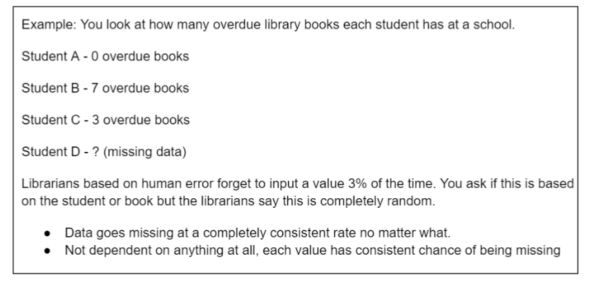

2. **Missing at Random (MAR)**: The missingness is related to observed variables but not to the values of the missing data itself. In this case, the probability of data being missing can be predicted by other variables in the dataset (Seaman et al. 2013).

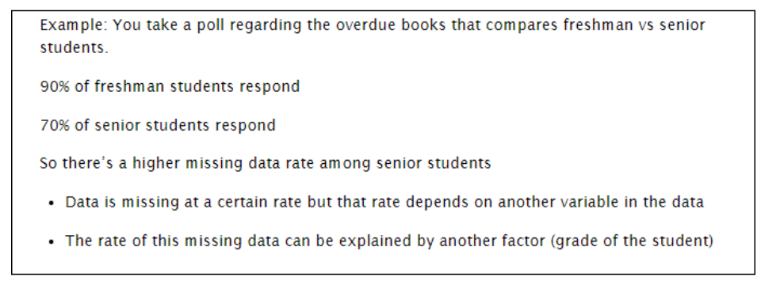

3. **Missing Not at Random (MNAR)**: The missingness is related to the values of the missing data itself, even after considering observed variables. This type of missing data can introduce bias and is often more challenging to handle (Umathe and Chaudhary 2015).

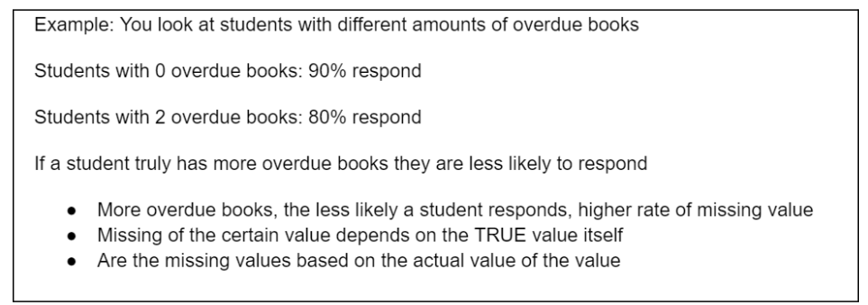

**Data imputation** is a technique that aims to replace the missing data with a substitute value. This technique can be applied when removing data from the dataset is not feasible. Due to reasons such as a reduction in the size of the dataset by a large extent. Reduction in this way can also raise concerns for biases and incorrect analysis, reduction can lead to distortion in the data variables and impact of the final model with biases. The goal is to restore the complete dataset and not lose any more of the data (Allison 2009).

## Literature Review

Handling missing data is crucial in statistical analysis because it can lead to biased or inefficient results if not addressed properly. Researchers employ various techniques, such as imputation methods, to estimate or replace the missing values and ensure the validity and reliability of their analyses. Imputation involves filling in missing values with plausible estimates based on the observed data or using statistical models to predict missing values. Researchers need to be aware of the nature and mechanisms of missing data in their datasets, as the choice of imputation method depends on these factors. Ignoring missing data or handling it incorrectly can impact the accuracy and generalizability of study findings (Kang 2013).

A dataset in which some of the data is missing and disrupts the completeness of the data is known as missing data. The missing data in a dataset leads to incorrect computations, and incorrect output for the created pipelines leading to inaccurate predictions which could ultimately lead to the downfall of the business. Filling those missing data with substituted values is called data imputation. It is very important to handle missing values effectively during the process (Kaiser 2012).

An example of a single imputation method would be mean and median imputation. This method acts to replace the missing data with statistical approximations of the missing data. The main object of this being to create a complete dataset (Pigott 2001). In the method one will see these missing values replaced by the mean or median, depending on if the distribution is normal or skewed. If normal one could use mean imputation and if skewed one could utilize median imputation. Assumptions regarding this method would be that the data is missing completely at random (MCAR). Advantages of the mean/median method are also it’s simple and quick regarding obtaining the complete dataset. Disadvantages of the mean/median method are that it distorts the original variance as well as the covariance regarding variables left-over in the dataset (Zhang 2016).

There is also a simple missing data handling method such as deletion. This involves removing rows or columns in the dataset. Which can be done via drop_na() or na.omit(). Some advantages of this method would be the easy of use along with reducing the dataset’s size and complexity. Replacing missing data with certain values can cause errors or biases. This method may also help to preserve the original distribution of the data as well as the variance. Disadvantages of the deletion method would be possible loss of valuable information and reduction of the dataset’s sample size. If the values deleted were not random or independent this can cause distortion and introduce bias. Thus the data becomes less informative and inaccurate. Alternatives to this are other missing data handling methods such as imputation (Baraldi and Enders 2010).

Another technique is multiple imputation. This imputation method is an approach to missing data applied to common statistical packages. Multiple imputation is used to allow for the uncertainty of the missing data via creating many different plausible imputed datasets and appropriately mixing results produced from each of them (Sinharay, Stern, and Russell 2001). The first step is to create multiple copies of the dataset with the missing values substituted via the imputed values since we can never know the true values of the missing data, this imputation course of action should capture fully all uncertainty in foreseeing the missing values by inserting appropriate variability into the multiple imputed values. The second stage is to utilize a standard statistical method. This method should fit the model of interest for each of the datasets that experienced imputation (Sterne et al. 2009).

Other imputation techniques consist of complete case analysis (CCA), arbitrary value imputation, and frequent category imputation. Complete case analysis involves directly removing the rows that have missing data. This is also known as a listwise deletion. The assumption is the data is missing at random (MAR). Arbitrary value imputation involves handling both numerical and categorical variables (White and Carlin 2010). This technique additionally includes grouping the missing values in a column and then a value far from the range of the column. The values could be 999999, - 999999, missing or not defined. The assumption for this technique is the data is not missing at random. Furthermore, frequent category imputation is a technique that replaces the missing value with the variable that has the highest frequency, meaning one replaces the value with the mode of the column. This is also called mode imputation. The assumption regarding this technique is that the data is missing at random (Ross, Breskin, and Westreich 2020).

Overall it’s important to understand the reasons behind why data is missing. This allows the rest of the data to be handled correctly. One can conclude that if the data is missing completely at random (MCAR) one likely still has data that is representative of the population. Although if the data is missing systematically, one can infer the analysis could be potentially biased. This data bias can be described as when the values or information is limited in some manner (Westreich 2012). Missing data additionally reduces statistical power and leads to invalid conclusions. Statistical power is the ability to detect an effect when utilizing a significance test. A low power can imply the test has a smaller chance of detecting a true effect. Or it may imply results are distorted via systematic or random error (Davey et al. 2009). Missing data can also be difficult because one sometimes cannot accurately identify the problem. Because of these issues researchers will design studies to try and minimize occurrences of missing data.

#### Other Applications: Electronic Health Record (EHR)

The EHR has increasingly become used for data mining and analysis for a variety of health conditions. However, due to irregular observation times and innate uncertainties in a medical setting, the EHR datasets are missing values. The EHR systems were not created in mind for research. Researchers who do use this data may categorize this missing data as missing completely at random, missing at random, or not missing at random. Regarding missing completely at random (MCAR) data, all of the data points have the same odds to be missing. Missing at random is attributable to things like the patient’s condition, which means the missingness of the data is independent of the value of the data. Not missing random data completely depends on the value of the data. For each of these categories, the level of bias can be different (Jazayeri, Liang, and Yang 2020).

Additionally it is something to consider that the EHR can reflect health inequity. Patients who belong to different groups may have different amounts of data in their health record. This can also result in biases in the data collection process. Missing data can also be caused by fragmented care in certain under-served groups. This results in the data being collected to be less informative (Rozier, Patel, and Cross 2022).

## Methods

When confronted with missing data there are 2 primary pathways to handle the missing data. This is either imputation or data removal. Imputation substitues estimates for missing values. Removal of the data is to deleting the missing values and thus missing information. Depending on the data type, some methods are better than others at preserving variance and original distribution of the data (Salgado et al. 2019).

**Mean/Median Imputation**  
This is simple single imputation method, one will take the average or common value and fill in for those missing values. This method has the assumption data is missing completely at random (MCAR) so one could apply this method to MCAR data. Mean imputation should be utlizied when distribution is normal and median imputation if distribution of data is skewed. This method can also artificially reduce variability of data. When one has a of missing data to fill in and you fill in with the exact same value. Variance and standard deviation decreases which is not necessarily desirable.

Replace missing values with the mean or median of the observed values in the variable

The mean() and median() functions in R can be used for this method.

[figure not shown]

In both cases, missing values are replaced with the mean or median of the observed values in the variable (X) (Jadhav, Pramod, and Ramanathan 2019)

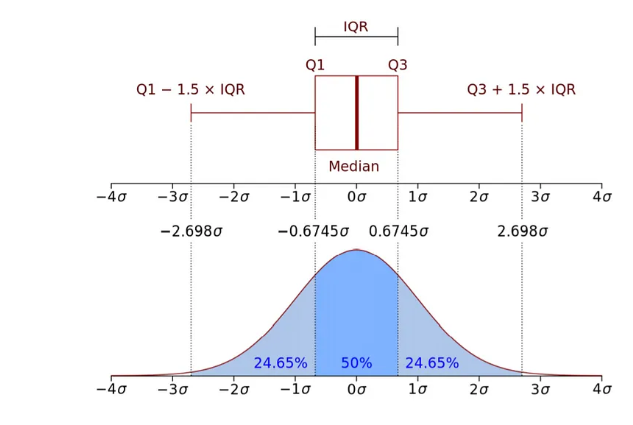

Figure 1: Mean/Median Imputation Normal Distribution. Image by Arun Amballa (2020) via medium.com

**Multiple Imputation**

Instead of inputting a single value for the missing value. Multiple imputations attempts to input multiple values into the missing value and run analysis with completed data sets in all those cases, then average the results to get an unbiased estimate (Wayman 2003).

- Generate multiple sets of plausible values for each missing data point, considering the uncertainty associated with imputation.
  - The `mice` (Multivariate Imputation by Chained Equations) package in R is commonly used for multiple imputation.

The multiple imputation process involves three steps:

a) Imputation (m times): Generate (m) imputed datasets, where missing values are filled using a specified imputation method.

b) Analysis (m times): Analyze each imputed dataset separately using the desired statistical analysis.

c) Pooling: Combine the results from the (m) analyses to obtain final estimates and standard errors.

The imputation step often involves drawing imputed values from a predictive distribution based on observed data (Goeij et al. 2013).

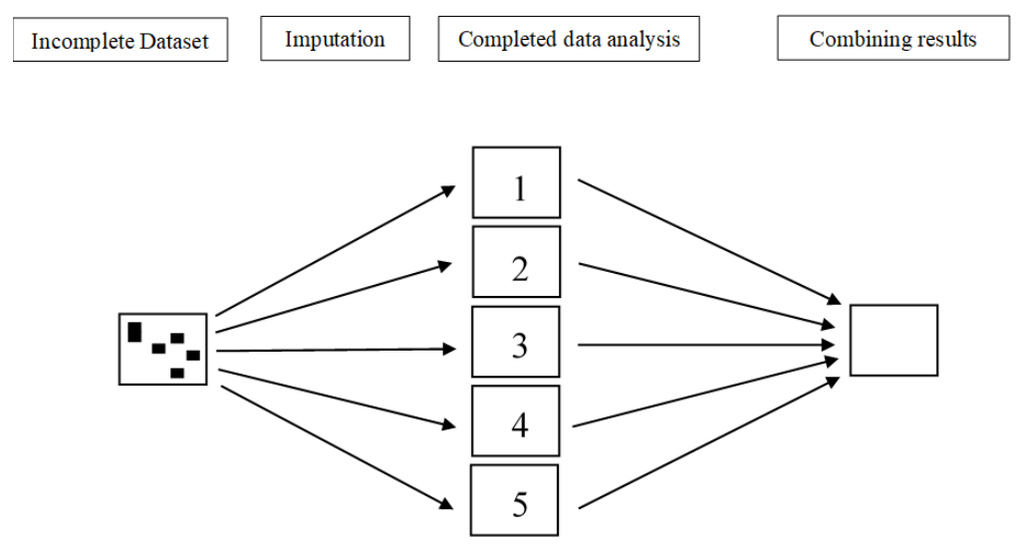

Figure 2: Missing data value replaced by several different values . Image by Martijn W Heymans and Iris Eekhout (2019) via bookdown.org

**K-Nearest Neighbors (KNN) Imputation**

Advanced technique that fills missing values via estimating them by the characteristics of similar neighboring data points.

Impute missing values based on the values of their nearest neighbors in the dataset.

The `impute.knn()` function in the `impute` package is a popular choice for KNN imputation.

**Most Frequent Value Imputation**

Also known as mode imputation, this is when the most frequent value replaces the missing values.This can be the most frequent value or most frequent category. This also may enable over-representation of the frequent variable.

Method: Replace missing values with the most frequently occurring value in the variable. - Application: Appropriate for categorical variables or when missing values are likely to be the mode (Sessa and Syed 2016).

## Analysis and Results

#### Data Description

**Survival Statistics:**

**Data Distribution:** The data has been distributed as per the class, below is the information on how the data has been distributed between the people.

Total: 1309 people

**Fields in the Dataset:**

[output not shown]

**Missing Variables Plot:s**

This script displays which variables have contain the most missing variables in the titantic data via gg_miss_var function

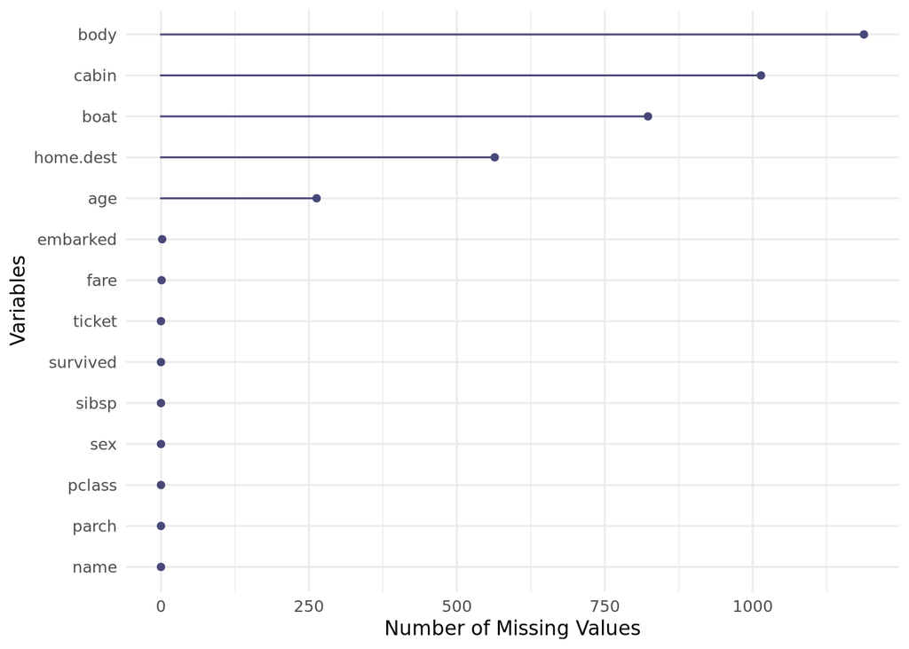

```r
# Install and load necessary packages
#install.packages("tidyverse")
#library(tidyverse)
#install.packages("readxl")
library(readxl)
your_data <- read_excel("Titanic_dataset.xlsx")

install.packages("naniar",repos = "http://cran.us.r-project.org")
library("naniar")
library(ggplot2)

gg_miss_var(your_data) + labs(y = "Number of Missing Values")
```

This script is done via vis_mis function to display the percentage of missing data regarding the variables.

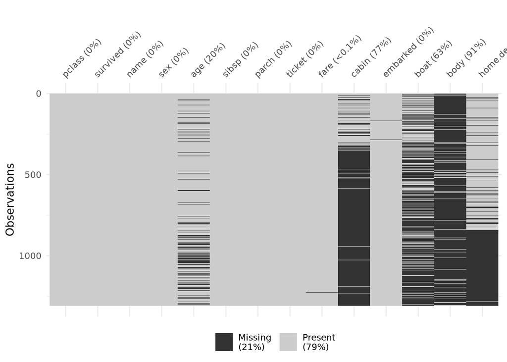

```r
vis_miss(your_data)
```

The code creates a plot that displays if there is a missing element in the dataset’s columns. Grey indicating that there is a missing element.

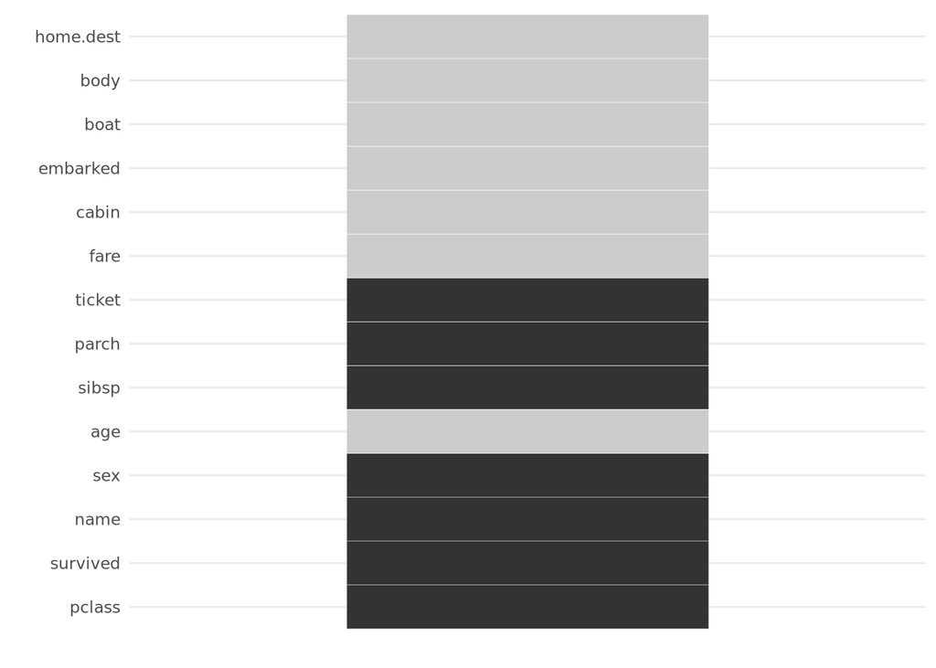

```r
gg_miss_which(your_data)
```

#### Pattern of Missing Data

Upon viewing the visualizations of the missing data distribution for the titanic data set. One can see certain fields contain the most missing values. These fields such as body, cabin, boat, age and home.dest. The missing variables percentage plot displays these percentages for the certain variables. One can also observe from the titatanic data set plots that overall 79% of the data is present and 21% is missing. Specifically, the body variable contains data which 91% is missing, followed by cabin 77% and boat 63%. One could consider that the variables such as body may be influenced by another factor when hypothesizing what kind of missing data type each of these fields belong to and what imputation methods one could apply.

The code involves installing and loading the “tidyverse” package, which provides a variety of tools for data science jobs, as well as loading the “readxl” package for handling Excel files.

```r
# Install and load necessary packages
#install.packages("tidyverse")
#library(tidyverse)
#install.packages("readxl")
library(readxl)
```

The code computes missing values for particular variables, specifies columns for imputation, reads the Titanic dataset, and produces counts. At present, the ‘age’ column missing 263 values.

```r
your_data <- read_excel("Titanic_dataset.xlsx")
#head(your_data)

# Define the columns for which you want to perform imputation
columns_to_impute <- c("pclass", "survived", "age", "sibsp", "parch", "fare")

missing_age <- sum(is.na(your_data$age))
missing_cabin <- sum(is.na(your_data$cabin))
missing_boat <- sum(is.na(your_data$boat))
missing_body <- sum(is.na(your_data$body))
missing_home_dest <- sum(is.na(your_data$home.dest))
```

```r
# Print the counts of missing values
cat("Missing values in 'age':", missing_age, "\n")
```

```
Missing values in 'age': 263
```

```r
#Missing values in 'age': 263
```

The code shows that there are 823 missing values in the “boat” and 1014 missing values in the “cabin.”

```r
cat("Missing values in 'cabin':", missing_cabin, "\n")
```

```
Missing values in 'cabin': 1014
```

```r
#Missing values in 'cabin': 1014
```

The code shows 1188 missing values in the “body” and 823 missing values in the “boat.”

```r
cat("Missing values in 'body':", missing_body, "\n")
```

```
Missing values in 'body': 1188
```

```r
#Missing values in 'body': 1188
```

```r
cat("Missing values in 'boat':", missing_boat, "\n")
```

```
Missing values in 'boat': 823
```

```r
#Missing values in 'boat': 823
```

The code shows 564 missing values in the “home.dest”

```r
cat("Missing values in 'home.dest':", missing_home_dest, "\n")
```

```
Missing values in 'home.dest': 564
```

```r
#Missing values in 'home.dest': 564
```

2. **Multiple Imputation**

The Titanic dataset is imported into the R, which then chooses which columns to imputation. Multiple imputation is then carried out using predictive mean matching, and the results are saved as imputed data.

```r
# Install and load necessary packages
# install.packages("mice")
# install.packages("openxlsx")
library(mice)
library(openxlsx)

# Load the Titanic dataset
your_data <- read_excel("Titanic_dataset.xlsx")

# Define the columns for which you want to perform imputation
columns_to_impute <- c("pclass", "survived", "age", "sibsp", "parch", "fare")

# Create a copy of the original data to preserve the original dataset
imputation_data <- your_data

# Set the seed for reproducibility
set.seed(123)

# Perform multiple imputation
imputed_data <- mice(imputation_data[, columns_to_impute], m = 5, method = 'pmm')
```

```r
# Other imputation methods: 'logreg' for logistic regression, 'rf' for random forest

# Complete the imputation process
completed_data <- complete(imputed_data)

# Save the imputed dataset using openxlsx
write.xlsx(completed_data, "Imputed_Titanic_dataset_MultipleImputation.xlsx")

# Display summary statistics of the imputed dataset
summary(completed_data)
```

```
     pclass         survived          age              sibsp
 Min.   :1.000   Min.   :0.000   Min.   : 0.1667   Min.   :0.0000
 1st Qu.:2.000   1st Qu.:0.000   1st Qu.:19.0000   1st Qu.:0.0000
 Median :3.000   Median :0.000   Median :27.0000   Median :0.0000
 Mean   :2.295   Mean   :0.382   Mean   :28.4482   Mean   :0.4989
 3rd Qu.:3.000   3rd Qu.:1.000   3rd Qu.:37.0000   3rd Qu.:1.0000
 Max.   :3.000   Max.   :1.000   Max.   :80.0000   Max.   :8.0000
     parch            fare
 Min.   :0.000   Min.   :  0.000
 1st Qu.:0.000   1st Qu.:  7.896
 Median :0.000   Median : 14.454
 Mean   :0.385   Mean   : 33.276
 3rd Qu.:0.000   3rd Qu.: 31.275
 Max.   :9.000   Max.   :512.329
```

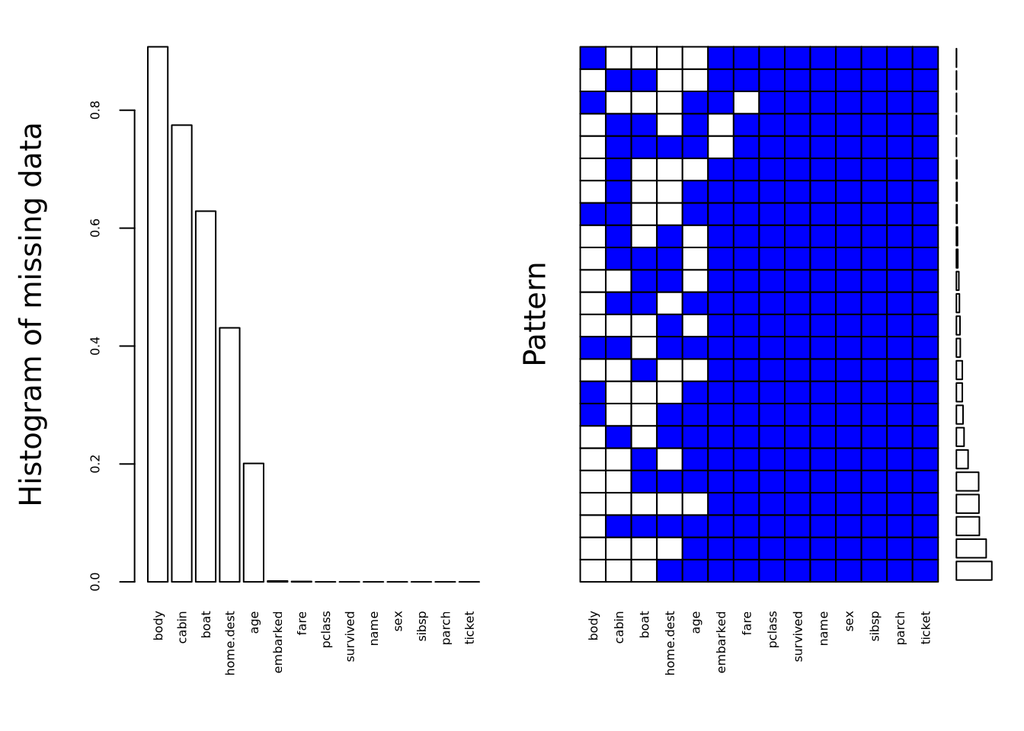

```
 Variables sorted by number of missings:
  Variable        Count
      body 0.9075630252
     cabin 0.7746371276
      boat 0.6287242170
 home.dest 0.4308632544
       age 0.2009167303
  embarked 0.0015278839
      fare 0.0007639419
    pclass 0.0000000000
  survived 0.0000000000
      name 0.0000000000
       sex 0.0000000000
     sibsp 0.0000000000
     parch 0.0000000000
    ticket 0.0000000000
```

```r
# Install and load necessary packages
# install.packages("readxl")
#install.packages("VIM")
library(readxl)
library(VIM)

# Load the Titanic dataset
your_data <- read_excel("Titanic_dataset.xlsx")

# Display missing data pattern
aggr(your_data, col = c("blue", "white"), numbers = TRUE, sortVars = TRUE, labels = names(your_data), cex.axis = 0.5, gap = 3, ylab = c("Histogram of missing data", "Pattern"))
```

4. **Most Frequent Value Imputation**

```r
# Load necessary packages
# install.packages("readxl")
# install.packages("Hmisc")
library(readxl)
library(Hmisc)

# Load the Titanic dataset
your_data <- read_excel("Titanic_dataset.xlsx")

# Define the columns with missing data
columns_with_missing <- c("Sex", "Fare", "Cabin", "Embarked", "Boat", "Body", "Home.Dest")

# Perform imputation with the most frequent value for each column
imputed_data <- your_data
for (col in columns_with_missing) {
  # Check if the column has missing values
  if (anyNA(imputed_data[[col]])) {
    # Impute missing values with the most frequent value
    imputed_data[[col]] <- impute(imputed_data[[col]], fun=function(x) {
      tab <- table(x)
      levels <- names(tab)[tab == max(tab)]
      x[is.na(x)] <- levels[1]
      x
    })
  }
}

# Display the count of missing values for each column after imputation
missing_counts <- colSums(is.na(imputed_data))
print("Missing values for each column after imputation:")
```

```
[1] "Missing values for each column after imputation:"
```

```r
"Missing values for each column after imputation:"
```

```
[1] "Missing values for each column after imputation:"
```

Prints count of missing values for each column.

```r
print(missing_counts)
```

```
   pclass  survived      name       sex       age     sibsp     parch    ticket
        0         0         0         0       263         0         0         0
     fare     cabin  embarked      boat      body home.dest
        1      1014         2       823      1188       564
```

### Data Visualization

**Scatterplot Matrix:**

Installing and loading the GGally package, choosing numerical variables, and utilizing the ggpairs function to construct a scatterplot matrix for analysis are all done by the code.

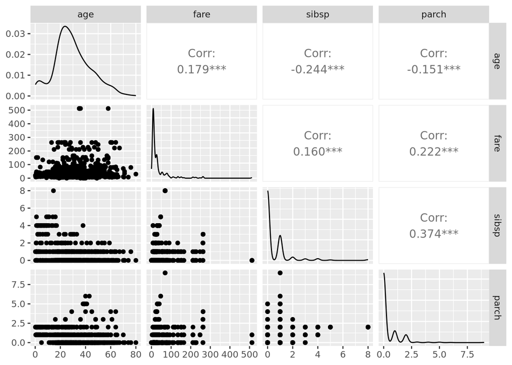

```r
# Install and load GGally package
#install.packages("GGally")
library(GGally)

# Select numeric variables
numeric_variables <- c("age", "fare", "sibsp", "parch")

# Create scatterplot matrix
ggpairs(your_data[, numeric_variables])
```

**Multiple Correspondence Analysis (MCA) Plot:**

The code in this article demonstrates the results of Multiple Correspondence Analysis (MCA) on the Titanic dataset using the FactoMineR package.

[figure not shown]

```r
# Install FactoMineR package
#install.packages("FactoMineR")

# Load FactoMineR package
library(FactoMineR)


# Perform MCA
mca_result <- MCA(your_data, graph = FALSE)

# Plot MCA
plot.MCA(mca_result)
```

**Density Plots Before and After Imputation:**

```r
# Install and load necessary packages
#install.packages("mice")
library(mice)

# Load the Titanic dataset
your_data <- read_excel("Titanic_dataset.xlsx")

# Define the columns for imputation
columns_to_impute <- c("age", "fare", "sibsp", "parch")

# Perform imputation
imputed_data <- complete(mice(your_data[, columns_to_impute], m = 1))
```

Two plots are laid out in the draft. It displays the distribution both before and after imputation by first creating a density plot for the ‘age’ variable from the original dataset and then another density plot for the ‘age’ variable from the imputed dataset.

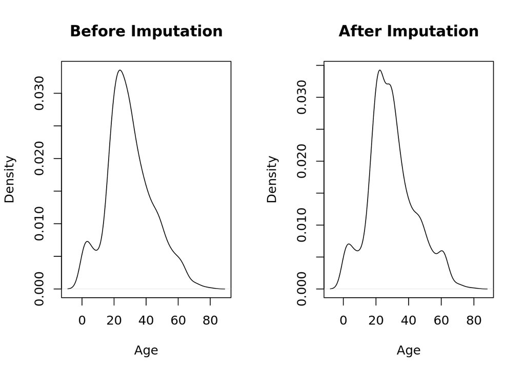

```r
# Create density plot before imputation
par(mfrow = c(1, 2))
plot(density(your_data$age, na.rm = TRUE), main = "Before Imputation", ylab = "Density", xlab = "Age")

# Create density plot after imputation
plot(density(imputed_data$age), main = "After Imputation", ylab = "Density", xlab = "Age")
```

**Heatmap of Correlation Matrix:**

For numerical variables, the script computes correlation matrices both before and after imputation and then generates heatmaps to show correlations. Correlations before imputation are shown in the “Before Imputation” heatmap. After imputation, the script creates a heatmap that shows correlations and the relationship between the variables.

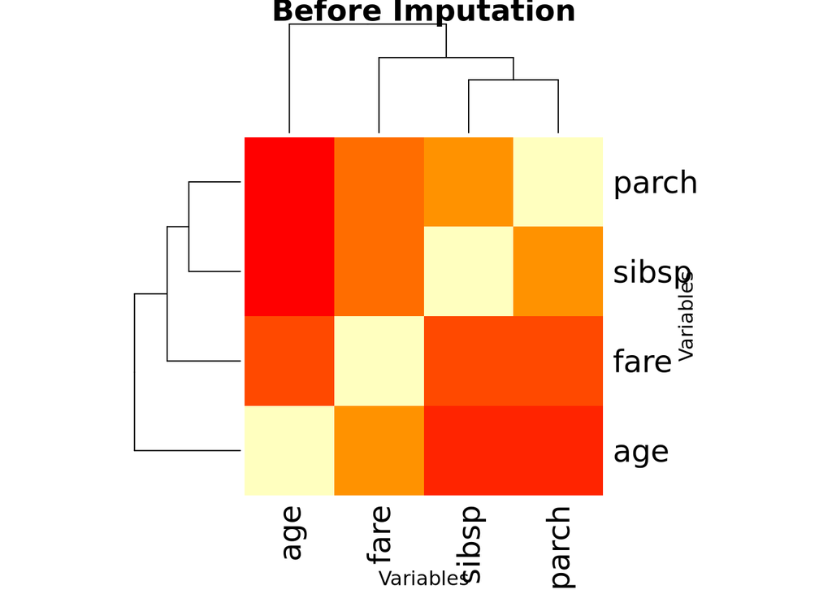

```r
# Compute correlation matrix before and after imputation
cor_before <- cor(your_data[, numeric_variables], use = "pairwise.complete.obs")
cor_after <- cor(completed_data[, numeric_variables], use = "pairwise.complete.obs")

# Create heatmaps
par(mfrow = c(1, 2))
heatmap(cor_before, main = "Before Imputation", xlab = "Variables", ylab = "Variables", col = heat.colors(10))
```

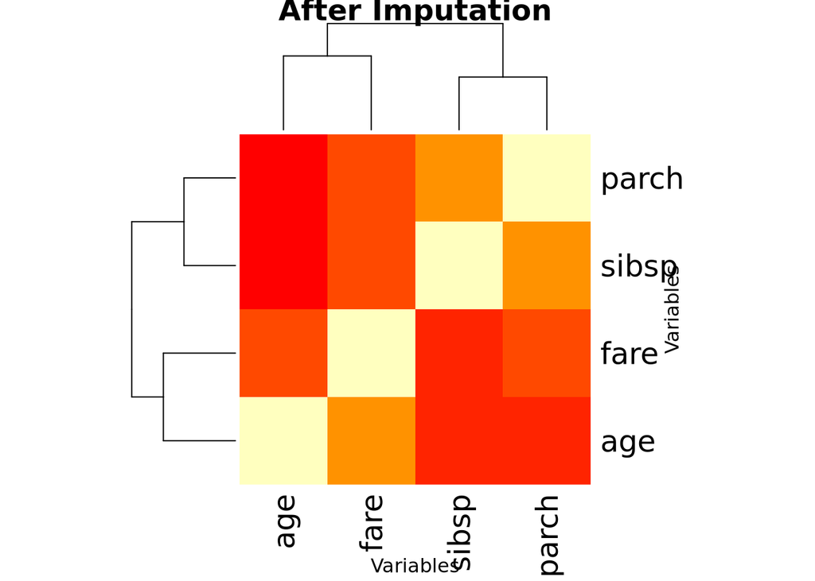

```r
heatmap(cor_after, main = "After Imputation", xlab = "Variables", ylab = "Variables", col = heat.colors(10))
```

**Violin Plots Before and After Imputation:**

This code depicts entire distribution of numeric data between titanic variables.

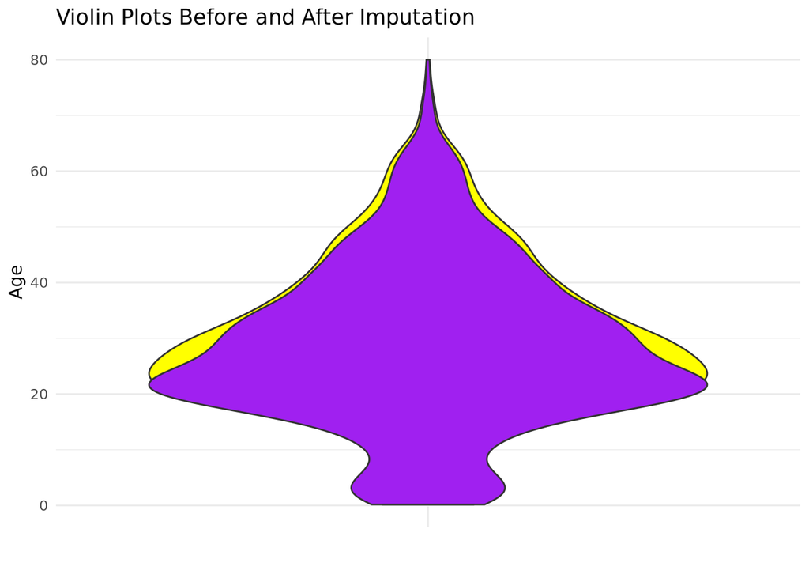

```r
library(ggplot2)
ggplot() +
  geom_violin(data = your_data, aes(x = "", y = age), fill = "yellow") +
  geom_violin(data = completed_data, aes(x = "", y = age), fill = "purple") +
  labs(title = "Violin Plots Before and After Imputation", x = "", y = "Age") +
  theme_minimal()
```

## References

Akmam, Emha Fathul, Titin Siswantining, Saskya Mary Soemartojo, and Devvi Sarwinda. 2019. “Multiple Imputation with Predictive Mean Matching Method for Numerical Missing Data.” In *2019 3rd International Conference on Informatics and Computational Sciences (ICICoS)*, 1–6. IEEE.

Allison, Paul D. 2009. “Missing Data.” *The SAGE Handbook of Quantitative Methods in Psychology*, 72–89.

Baraldi, Amanda N, and Craig K Enders. 2010. “An Introduction to Modern Missing Data Analyses.” *Journal of School Psychology* 48 (1): 5–37.

Davey, Adam et al. 2009. *Statistical Power Analysis with Missing Data: A Structural Equation Modeling Approach*. Routledge.

Goeij, Moniek CM de, Merel Van Diepen, Kitty J Jager, Giovanni Tripepi, Carmine Zoccali, and Friedo W Dekker. 2013. “Multiple Imputation: Dealing with Missing Data.” *Nephrology Dialysis Transplantation* 28 (10): 2415–20.

Jadhav, Anil, Dhanya Pramod, and Krishnan Ramanathan. 2019. “Comparison of Performance of Data Imputation Methods for Numeric Dataset.” *Applied Artificial Intelligence* 33 (10): 913–33.

Jazayeri, Ali, Ou Stella Liang, and Christopher C Yang. 2020. “Imputation of Missing Data in Electronic Health Records Based on Patients’ Similarities.” *Journal of Healthcare Informatics Research* 4 (3): 295–307.

Kaiser, Jiřı́. 2012. “Algorithm for Missing Values Imputation in Categorical Data with Use of Association Rules.” *arXiv Preprint arXiv:1211.1799*.

Kang, Hyun. 2013. “The Prevention and Handling of the Missing Data.” *Korean Journal of Anesthesiology* 64 (5): 402.

Kramer, Oliver, and Oliver Kramer. 2013. “K-Nearest Neighbors.” *Dimensionality Reduction with Unsupervised Nearest Neighbors*, 13–23.

Little, Roderick JA, and Donald B Rubin. 2019. *Statistical Analysis with Missing Data*. Vol. 793. John Wiley & Sons.

Pigott, Therese D. 2001. “A Review of Methods for Missing Data.” *Educational Research and Evaluation* 7 (4): 353–83.

Ross, Rachael K, Alexander Breskin, and Daniel Westreich. 2020. “When Is a Complete-Case Approach to Missing Data Valid? The Importance of Effect-Measure Modification.” *American Journal of Epidemiology* 189 (12): 1583–89.

Rozier, Michael D, Kavita K Patel, and Dori A Cross. 2022. “Electronic Health Records as Biased Tools or Tools Against Bias: A Conceptual Model.” *The Milbank Quarterly* 100 (1): 134–50.

Salgado, Cátia M, Carlos Azevedo, Hugo Proença, and Susana M Vieira. 2019. “Missing Data.”

Seaman, Shaun, John Galati, Dan Jackson, and John Carlin. 2013. “What Is Meant by ‘Missing at Random’?”

Sessa, Jadran, and Dabeeruddin Syed. 2016. “Techniques to Deal with Missing Data.” In *2016 5th International Conference on Electronic Devices, Systems and Applications (ICEDSA)*, 1–4. IEEE.

Sinharay, Sandip, Hal S Stern, and Daniel Russell. 2001. “The Use of Multiple Imputation for the Analysis of Missing Data.” *Psychological Methods* 6 (4): 317.

Sterne, Jonathan AC, Ian R White, John B Carlin, Michael Spratt, Patrick Royston, Michael G Kenward, Angela M Wood, and James R Carpenter. 2009. “Multiple Imputation for Missing Data in Epidemiological and Clinical Research: Potential and Pitfalls.” *Bmj* 338.

Umathe, Vaishali H, and Gauri Chaudhary. 2015. “Imputation Methods for Incomplete Data.” In *2015 International Conference on Innovations in Information, Embedded and Communication Systems (ICIIECS)*, 1–4. IEEE.

Wayman, Jeffrey C. 2003. “Multiple Imputation for Missing Data: What Is It and How Can i Use It.” In *Annual Meeting of the American Educational Research Association, Chicago, IL*, 2:16. Citeseer.

Westreich, Daniel. 2012. “Berkson’s Bias, Selection Bias, and Missing Data.” *Epidemiology* 23 (1): 159–64.

White, Ian R, and John B Carlin. 2010. “Bias and Efficiency of Multiple Imputation Compared with Complete-Case Analysis for Missing Covariate Values.” *Statistics in Medicine* 29 (28): 2920–31.

Zhang, Zhongheng. 2016. “Missing Data Imputation: Focusing on Single Imputation.” *Annals of Translational Medicine* 4 (1).